# Churn prediction

```python
%pylab inline --no-import-all

from scipy import interp

import pandas as pd
from pandas.api.types import CategoricalDtype

import sklearn
from sklearn import ensemble, model_selection, metrics
import xgboost
from xgboost import XGBClassifier

plt.rcParams['figure.figsize'] = (12, 8)
```

First we define some functions to convert data from the csv to Python types.

## Data loading and preprocessing

```python
def convert_bool(col, true_str="Yes", false_str="No"):
    """
    Convert string to boolean values.
    """
    if col ==  true_str: #check for nan
        return 1
    elif col == false_str:
        return 0
    else:
        raise ValueError(col)


def convert_float(col):
    """
    Convert floating point values. If it is not possible, it returns 0.

    This is useful for the TotalCharges columns, since it contains
    empty cells when it should be 0.
    """
    try:
        return float(col)
    except ValueError:
        return 0
```

```python
categorical_no_internet = CategoricalDtype(categories=["No internet service", "No", "Yes"])

df = pd.read_csv(
    "Telco-Customer-Churn.csv",
    dtype={
        "MultipleLines": CategoricalDtype(categories=["No phone service", "No", "Yes"]),
        'InternetService': 'category',
        'OnlineSecurity': categorical_no_internet,
        'OnlineBackup': categorical_no_internet,
        'DeviceProtection': categorical_no_internet,
        'TechSupport': categorical_no_internet,
        'StreamingTV': categorical_no_internet,
        'StreamingMovies': categorical_no_internet,
        'Contract': 'category',
    #     'PaperlessBilling': 'category',
        'PaymentMethod': 'category',
    },
    converters={
        'gender': lambda x: convert_bool(x, 'Male', "Female"),
        'Partner': convert_bool,
        'Dependents': convert_bool,
        'PhoneService': convert_bool,
        'PaperlessBilling': convert_bool,
        'TotalCharges': convert_float,
        'Churn': convert_bool
    })

# TotalCharges is related to tenure and MonthlyCharges (TotalCharges is approx = to tenure*MonthlyCharges)
# Instead of storing TotalCharges, we just store the deviation between TotalCharges and tenure*MonthlyCharges.
df["discount"] = (df["tenure"] * df["MonthlyCharges"] - df["TotalCharges"])/(np.maximum(df["tenure"], 1))

y = df["Churn"].values
df = df.drop(labels=["customerID", "Churn", "TotalCharges"], axis=1)
```

```python
df.dtypes
```

```
gender                 int64
SeniorCitizen          int64
Partner                int64
Dependents             int64
tenure                 int64
PhoneService           int64
MultipleLines       category
InternetService     category
OnlineSecurity      category
OnlineBackup        category
DeviceProtection    category
TechSupport         category
StreamingTV         category
StreamingMovies     category
Contract            category
PaperlessBilling       int64
PaymentMethod       category
MonthlyCharges       float64
discount             float64
dtype: object
```

We convert categorical fields to multiple binary fields

```python
df_nocat = pd.get_dummies(df, drop_first=True)
df_nocat.dtypes
```

```
gender                                     int64
SeniorCitizen                              int64
Partner                                    int64
Dependents                                 int64
tenure                                     int64
PhoneService                               int64
PaperlessBilling                           int64
MonthlyCharges                           float64
discount                                 float64
MultipleLines_No                           uint8
MultipleLines_Yes                          uint8
InternetService_Fiber optic                uint8
InternetService_No                         uint8
OnlineSecurity_No                          uint8
OnlineSecurity_Yes                         uint8
OnlineBackup_No                            uint8
OnlineBackup_Yes                           uint8
DeviceProtection_No                        uint8
DeviceProtection_Yes                       uint8
TechSupport_No                             uint8
TechSupport_Yes                            uint8
StreamingTV_No                             uint8
StreamingTV_Yes                            uint8
StreamingMovies_No                         uint8
StreamingMovies_Yes                        uint8
Contract_One year                          uint8
Contract_Two year                          uint8
PaymentMethod_Credit card (automatic)      uint8
PaymentMethod_Electronic check             uint8
PaymentMethod_Mailed check                 uint8
dtype: object
```

Get values in NumPy's array format

```python
x = df_nocat.values
```

Variables x and y contain the features and the class to predict, respectively.

## Classification

Since y is a boolean array, we will use classifiers to predict y given x.

We will use two different classifiers: RandomForestClassifier from sklearn and the boosting classifier from XGBoost.

```python
# We use 1000 estimators (trees)
clsf_forest = ensemble.RandomForestClassifier(n_estimators=1000)
clsf_boost = XGBClassifier(n_estimators=1000)
```

### Cross-validation

```python
def cv_roc(clsf, x, y, n_splits=4):

    results = {'tpr': [], 'fpr': [], 'average_precision': [], "roc_auc": [], "accuracy": []}

    mean_tpr = 0.0
    mean_fpr = np.linspace(0, 1, 100)

    cv = model_selection.StratifiedKFold(n_splits=n_splits)
    for train_idx, test_idx in cv.split(x, y):
        train_x, train_y = x[train_idx], y[train_idx]
        test_x, test_y = x[test_idx], y[test_idx]

        clsf.fit(train_x, train_y)

        y_pred = clsf.predict_proba(test_x)[:, 1]

        fpr, tpr, _ = metrics.roc_curve(test_y, y_pred)
        mean_tpr += interp(mean_fpr, fpr, tpr)
        mean_tpr[0] = 0.0

        results['fpr'].append(fpr)
        results['tpr'].append(tpr)
        results['average_precision'].append(metrics.average_precision_score(test_y, y_pred))
        results['roc_auc'].append(metrics.roc_auc_score(test_y, y_pred))

        results['accuracy'].append(metrics.accuracy_score(test_y, y_pred>0.5))

    mean_tpr /= n_splits
    mean_tpr[-1] = 1.0

    return {
        'mean_fpr': mean_fpr,
        'mean_tpr': mean_tpr,
        **{k: np.array(v) for k, v in results.items()}
    }
```

```python
results_forest = cv_roc(clsf_forest, x, y)
```

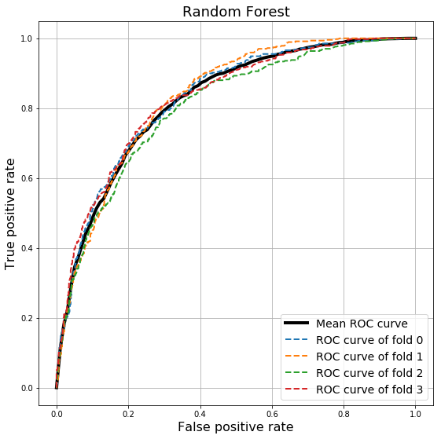

```python
plt.figure(figsize=(9, 9))
plt.plot(results_forest['mean_fpr'], results_forest['mean_tpr'],
         color='black', linewidth=4, label="Mean ROC curve")

for i, (fpr, tpr) in enumerate(zip(results_forest['fpr'], results_forest['tpr'])):
    plt.plot(fpr, tpr, linewidth=2, linestyle='--', label="ROC curve of fold {}".format(i))

plt.legend(loc='lower right', fontsize=14)
plt.xlabel("False positive rate", fontsize=16)
plt.ylabel("True positive rate", fontsize=16)
plt.grid()

plt.title("Random Forest", fontsize=18)
```

```python
results_boost = cv_roc(clsf_boost, x, y)
```

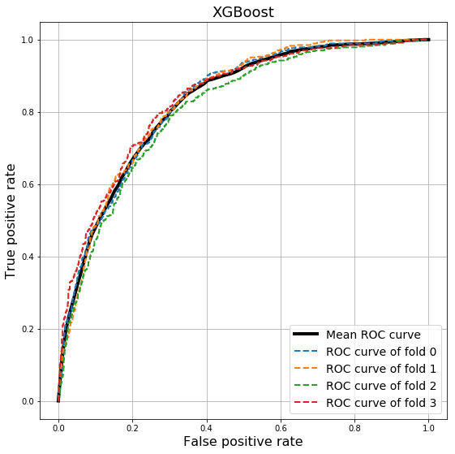

```python
plt.figure(figsize=(9, 9))
plt.plot(results_boost['mean_fpr'], results_boost['mean_tpr'],
         color='black', linewidth=4, label="Mean ROC curve")

for i, (fpr, tpr) in enumerate(zip(results_boost['fpr'], results_boost['tpr'])):
    plt.plot(fpr, tpr, linewidth=2, linestyle='--', label="ROC curve of fold {}".format(i))

plt.legend(loc='lower right', fontsize=14)
plt.xlabel("False positive rate", fontsize=16)
plt.ylabel("True positive rate", fontsize=16)
plt.grid()

plt.title("XGBoost", fontsize=18)
```

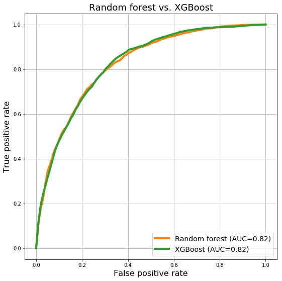

```python
plt.figure(figsize=(9, 9))

auc_forest = metrics.auc(results_forest['mean_fpr'], results_forest['mean_tpr'])
auc_boost = metrics.auc(results_boost['mean_fpr'], results_boost['mean_tpr'])

plt.plot(results_forest['mean_fpr'], results_forest['mean_tpr'],
         color='C1', linewidth=4, label="Random forest (AUC={:.2g})".format(auc_forest))
plt.plot(results_boost['mean_fpr'], results_boost['mean_tpr'],
         color='C2', linewidth=4, label="XGBoost (AUC={:.2g})".format(auc_boost))
plt.grid()

plt.legend(loc='lower right', fontsize=14)
plt.xlabel("False positive rate", fontsize=16)
plt.ylabel("True positive rate", fontsize=16)

plt.title("Random forest vs. XGBoost", fontsize=18)
```

The average accuracy of both models is:

```python
acc = results_boost["accuracy"]
print("XGBoost accuracy: {:.2f}%(stddev {:.2f})".format(acc.mean() * 100, acc.std()))
```

```
XGBoost accuracy: 78.70%(stddev 0.01)
```

```python
acc = results_forest["accuracy"]
print("Forest accuracy: {:.2f}%(stddev {:.2f})".format(acc.mean() * 100, acc.std()))
```

```
Forest accuracy: 78.99%(stddev 0.01)
```

There are two interesting conclusions from these results:

1. The performance of different folds is very similar. This suggests that the dataset is large enough and that we can work with a single training/testing split instead of using cross-validation.
2. The difference in performance of the random forest and XGBoost is negligible.

In the following discussion, we will evaluate the feature importance estimated by the random forest for the following split:

```python
train_x, test_x, train_y, test_y = model_selection.train_test_split(x, y, stratify=y)
```

We look at the feature importances computed by the random forest to understand which factors are more relevant for churn prediction.

```python
clsf_forest.fit(train_x, train_y)
```

```
RandomForestClassifier(bootstrap=True, class_weight=None, criterion='gini',
            max_depth=None, max_features='auto', max_leaf_nodes=None,
            min_impurity_decrease=0.0, min_impurity_split=None,
            min_samples_leaf=1, min_samples_split=2,
            min_weight_fraction_leaf=0.0, n_estimators=1000, n_jobs=None,
            oob_score=False, random_state=None, verbose=0,
            warm_start=False)
```

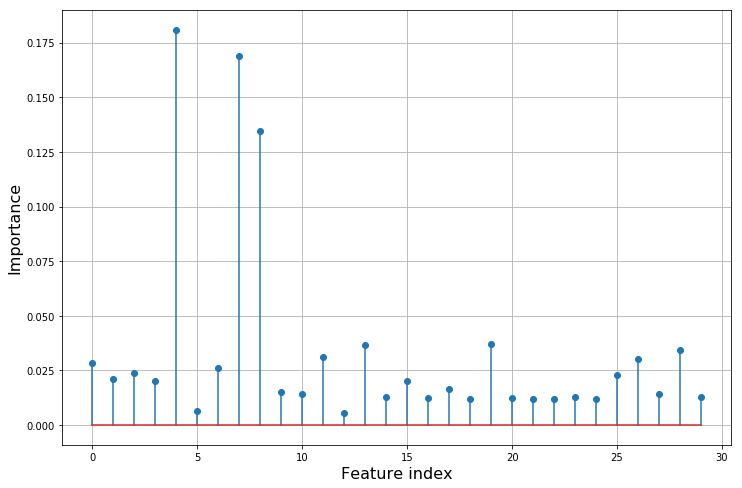

```python
plt.figure(figsize=(12, 8))
plt.stem(clsf_forest.feature_importances_)
plt.xlabel("Feature index", fontsize=16)
plt.ylabel("Importance", fontsize=16)
plt.grid()
```

We sort the columns of the dataset by the importance according to the random forest:

```python
indices = np.argsort(clsf_forest.feature_importances_)[::-1]
df_nocat.columns.values[indices]
```

```
array(['tenure', 'MonthlyCharges', 'discount', 'TechSupport_No',
       'OnlineSecurity_No', 'PaymentMethod_Electronic check',
       'InternetService_Fiber optic', 'Contract_Two year', 'gender',
       'PaperlessBilling', 'Partner', 'Contract_One year',
       'SeniorCitizen', 'OnlineBackup_No', 'Dependents',
       'DeviceProtection_No', 'MultipleLines_No',
       'PaymentMethod_Credit card (automatic)', 'MultipleLines_Yes',
       'PaymentMethod_Mailed check', 'StreamingMovies_No',
       'OnlineSecurity_Yes', 'OnlineBackup_Yes', 'TechSupport_Yes',
       'StreamingMovies_Yes', 'StreamingTV_No', 'DeviceProtection_Yes',
       'StreamingTV_Yes', 'PhoneService', 'InternetService_No'],
      dtype=object)
```

The most important factor for churn prediction is 'tenure', followed by MonthlyCharges.

We plot the histogram of tenure for customers with churn="no" and churn="yes" separately:

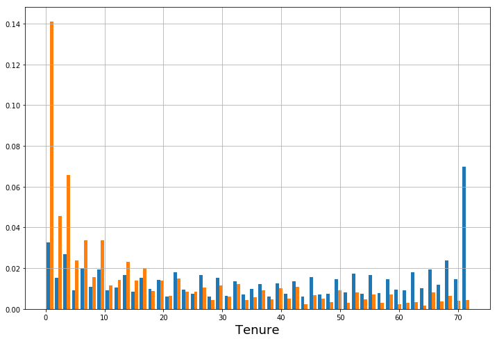

```python
_ = plt.hist([x[y==0, 4], x[y==1, 4]], 50, density=True)
plt.xlabel("Tenure", fontsize=18)
plt.grid()
```

As the histogram shows, customers with smaller tenure are more likely to churn than long-term customers.

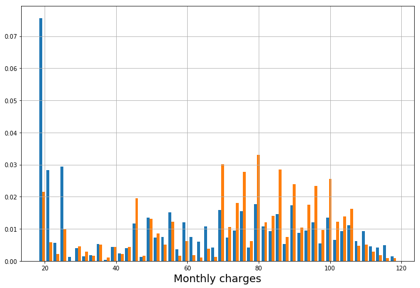

```python
_ = plt.hist([x[y==0, 7], x[y==1, 7]], 50, density=True)
plt.xlabel("Monthly charges", fontsize=18)
plt.grid()
```

As expected, customers with higher monthly charges are more likely to churn.